# Plotting

Her viser jeg hvordan vi aggreggerer indikatorverdiene til en verdi for økologisk tilstandsverdi og plotter denne. Det meste er scriptet er skrevet av Somon Jacobsson.

```r
# Number of simulations
nsim <- 10000 # should be run with 10 000 as the end

# Short names for ecosystem characteristics
characteristics <- c("ppr", "isf", "bmb", "fgw", "bio", "lsp", "abf")
```

# Step 1:

indicators, characteristics, years and period summaries

Specify reporting year key to periods

```r
periods <- data.frame(period = c(1,1,1,1,1,1,1,1,
                        2,2,2,2,2,
                        3,3,3,3,3,
                        4,4,4,4,4,
                        5,5,5,5,5,
                        6,6,6,6,6),
                      year = c(1988, 1989, 1990, 1991, 1992, 1993, 1994, 1995,
                        1996, 1997, 1998, 1999, 2000,
                        2001, 2002, 2003, 2004, 2005,
                        2006, 2007, 2008, 2009, 2010,
                        2011, 2012, 2013, 2014, 2015,
                        2016, 2017, 2018, 2019, 2020))
```

# Step 2:

load and adjust indicator data

# List files

List files with bootstrapped indicator values

```r
list.files(path = "../output/indicator_values/",
           pattern=".csv")
```

```
##  [1] "alien.csv"           "breareal.csv"        "ell_L_high.csv"
##  [4] "ell_L_low.csv"       "ell_N_high.csv"      "ell_N_low.csv"
##  [7] "ellenberg_alien.csv" "fjellindeks.csv"     "fjellrev.csv"
## [10] "fjellrype.csv"       "fragmentering.csv"   "heat_req.csv"
## [13] "inon.csv"            "jerv.csv"            "kongeorn.csv"
## [16] "lirype.csv"          "ndvi_lower.csv"      "ndvi_upper.csv"
## [19] "rein.csv"            "smågnagere.csv"      "snodekke.csv"
## [22] "snodybde.csv"        "varmekrav.csv"       "vinterregn.csv"
```

## Load and adjust data headings etc.

manual steps required due to different data structures

### Alien

```r
alien <- read.csv("../output/indicator_values/alien.csv", header=T)

alien$period <-
  periods$period[match(alien$year, periods$year)]

alien$X <- "alien"
```

### Breareal

```r
breareal <- read.csv("../output/indicator_values/breareal.csv", header=T)

breareal$period <-
  periods$period[match(breareal$year, periods$year)]

breareal$X <- "breareal"
```

### Ellenberg L

Denne indikatoren er tosidig (se her).

```r
EllLHigh <- read.csv("../output/indicator_values/ell_L_high.csv", header=T)
EllLLow <- read.csv("../output/indicator_values/ell_L_low.csv", header=T)

EllLHigh$period <-
  periods$period[match(EllLHigh$year, periods$year)]
EllLLow$period <-
  periods$period[match(EllLLow$year, periods$year)]


EllLHigh$X <- "EllLHigh"
EllLLow$X <- "EllLLow"
```

### Ellenberg N

Denne indikatoren er også tosidig (se her).

```r
EllNHigh <- read.csv("../output/indicator_values/ell_N_high.csv", header=T)
EllNLow <- read.csv("../output/indicator_values/ell_N_low.csv", header=T)

EllNHigh$period <-
  periods$period[match(EllNHigh$year, periods$year)]
EllNLow$period <-
  periods$period[match(EllNLow$year, periods$year)]

EllNHigh$X <- "EllNHigh"
EllNLow$X <- "EllNLow"
```

### Fjellindeks

```r
fjellindeks <- read.csv("../output/indicator_values/fjellindeks.csv", header=T)

fjellindeks$period <-
  periods$period[match(fjellindeks$year, periods$year)]

fjellindeks$X <- "fjellindeks"
```

### Fjellrev

```r
fjellrev <- read.csv("../output/indicator_values/fjellrev.csv", header=T)

fjellrev$period <-
  periods$period[match(fjellrev$year, periods$year)]

fjellrev$X <- "fjellrev"
table(fjellrev$reg, fjellrev$period)
```

```
##
##            1    2    4    5    6
##   C     1000 1000 1000 1000 1000
##   E     1000 1000 1000 1000 1000
##   N     1000 1000 1000 1000 1000
##   Norge 1000 1000 1000 1000 1000
##   S     1000 1000 1000 1000 1000
##   W     1000 1000 1000 1000 1000
```

### Fjellrype

Her må jeg skjekke litt.

```r
fjellrype <- read.csv("../output/indicator_values/fjellrype.csv", header=T)
fjellrype$X <- "fjellrype"
fjellrype$period <- periods$period[match(fjellrype$year, periods$year)]
```

### Fragmentering

Her må jeg skjekke litt.

```r
fragmentering <- read.csv("../output/indicator_values/fragmentering.csv", header=T)
fragmentering$year <- 2020
fragmentering$period <- periods$period[match(fragmentering$year, periods$year)]
```

### INON

INON har ingen usikkerhet knyttet til seg.

```r
inon <- read.csv("../output/indicator_values/inon.csv", header=T)
inon$X <- "INON"
inon$period <- periods$period[match(inon$year, periods$year)]
```

Er INON og Konnektivitetsindeksen korrelert?

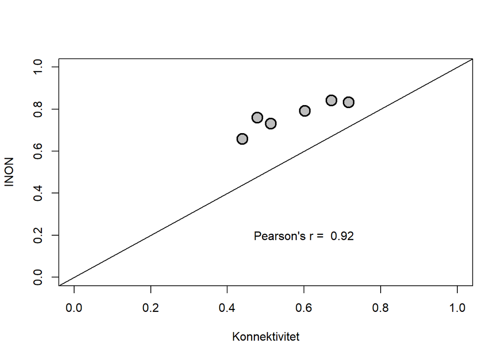

```r
plot(fragmentering$val,
     inon$val[inon$period==6],
     ylim = c(0,1), xlim=c(0,1),
     ylab = "INON", xlab = "Konnektivitet",
     col = "black", pch = 21, bg="grey", cex=2, lwd=2)
abline(a=0, b=1)
text(0.6, 0.2, paste("Pearson's r = ",
    round(cor(fragmentering$val,
         inon$val[inon$period==6]), 2)))
```

De er ganske korrelerte ja!

### Jerv

```r
jerv <- read.csv("../output/indicator_values/jerv.csv", header=T)

jerv$X <- "jerv"
jerv$period <-
  periods$period[match(jerv$year, periods$year)]
table(jerv$reg, jerv$period)
```

```
##
##            1    2    4    5    6
##   C     1000 1000 1000 1000 1000
##   E     1000 1000 1000 1000 1000
##   N     1000 1000 1000 1000 1000
##   Norge 1000 1000 1000 1000 1000
##   S     1000 1000 1000 1000 1000
##   W     1000 1000 1000 1000 1000
```

### Kongeørn

```r
kongeorn <- read.csv("../output/indicator_values/kongeorn.csv", header=T)

kongeorn$period <-
  periods$period[match(kongeorn$year, periods$year)]

kongeorn$X <- "kongeørn"
```

### Lirype

```r
lirype <- read.csv("../output/indicator_values/lirype.csv", header=T)
lirype$year <- 2020
lirype$period <-
  periods$period[match(lirype$year, periods$year)]

lirype$X <- "lirype"
```

### NDVI

```r
ndvi_upper <- read.csv("../output/indicator_values/ndvi_upper.csv", header=T)

ndvi_upper$year <- 2020
ndvi_upper$period <-
  periods$period[match(ndvi_upper$year, periods$year)]
ndvi_upper <- dplyr::select(ndvi_upper, -X.1)
table(ndvi_upper$reg)
```

```
##
##     C     E     N Norge     S     W
## 10000 10000 10000 10000 10000 10000
```

```r
ndvi_lower <- read.csv("../output/indicator_values/ndvi_lower.csv", header=T)

ndvi_lower$year <- 2020
ndvi_lower$period <-
  periods$period[match(ndvi_lower$year, periods$year)]
ndvi_lower <- dplyr::select(ndvi_lower, -X.1)
table(ndvi_lower$reg)
```

```
##
##     C     E     N Norge     S     W
## 10000 10000 10000 10000 10000 10000
```

### Rein

```r
rein <- read.csv("../output/indicator_values/rein.csv", header=T)

rein$period <-
  periods$period[match(rein$year, periods$year)]
table(rein$reg, rein$period)
```

```
##
##            6
##   C      500
##   E      500
##   N      500
##   Norge 1000
##   S      500
##   W      500
```

### Snødekke

```r
snodekke <- read.csv("../output/indicator_values/snodekke.csv", header=T)
snodekke$X <-  "snodekke"
snodekke$period <-
  periods$period[match(snodekke$year, periods$year)]
table(snodekke$reg, snodekke$period)
```

```
##
##             6
##   C     10000
##   E     10000
##   N     10000
##   Norge 10000
##   S     10000
##   W     10000
```

### Snødybde

```r
snodybde <- read.csv("../output/indicator_values/snodybde.csv", header=T)
snodybde$period <-
  periods$period[match(snodybde$year, periods$year)]
table(snodybde$reg, snodybde$period)
```

```
##
##             6
##   C     10000
##   E     10000
##   N     10000
##   Norge 10000
##   S     10000
##   W     10000
```

### Smågnagere

```r
smaagnagere <- read.csv("../output/indicator_values/smågnagere.csv", header=T)
smaagnagere$X <-  "smaagnagere"
smaagnagere$period <-
  periods$period[match(smaagnagere$year, periods$year)]
table(smaagnagere$reg, smaagnagere$period)
```

```
##
##             1     2     4     5     6
##   C     10000 10000 10000 10000 10000
##   E     10000 10000 10000 10000 10000
##   N     10000 10000 10000 10000 10000
##   Norge 10000 10000 10000 10000 10000
##   S     10000 10000 10000 10000 10000
##   W     10000 10000 10000 10000 10000
```

### Vegetasjonen varmekrav

Fjernes?

```r
varmekrav <- read.csv("../output/indicator_values/varmekrav.csv", header=T)
varmekrav <- dplyr::select(varmekrav, -X.1)
varmekrav$X <- "varmekrav"
varmekrav$period <-
  periods$period[match(varmekrav$year, periods$year)]
```

### Vinterregn

```r
vinterregn <- read.csv("../output/indicator_values/vinterregn.csv", header=T, encoding = "UTF-16")

vinterregn$X <- "vinterregn"

vinterregn$period <-
  periods$period[match(vinterregn$year, periods$year)]

table(vinterregn$reg, vinterregn$period)
```

```
##
##             6
##   C     10000
##   E     10000
##   N     10000
##   Norge 10000
##   S     10000
##   W     10000
```

# Step 3: Combine datasets

```r
# Periods to use
periods_use <- 6
```

Subset additional data

```r
alien            <- alien[alien$period%in%periods_use,]
breareal         <- breareal[breareal$period%in%periods_use,]
EllLHigh         <- EllLHigh[EllLHigh$period%in%periods_use,]
EllLLow          <- EllLLow[EllLLow$period%in%periods_use,]
EllNHigh         <- EllNHigh[EllNHigh$period%in%periods_use,]
EllNLow          <- EllNLow[EllNLow$period%in%periods_use,]
fjellindeks      <- fjellindeks[fjellindeks$period%in%periods_use,]
fjellrev         <- fjellrev[fjellrev$period%in%periods_use,]
fjellrype        <- fjellrype[fjellrype$period%in%periods_use,]
fragmentering    <- fragmentering[fragmentering$period%in%periods_use,]
inon             <- inon[inon$period%in%periods_use,]
jerv             <- jerv[jerv$period%in%periods_use,]
kongeorn         <- kongeorn[kongeorn$period%in%periods_use,]
lirype           <- lirype[lirype$period%in%periods_use,]
ndvi_upper       <- ndvi_upper[ndvi_upper$period%in%periods_use,]
ndvi_lower       <- ndvi_lower[ndvi_lower$period%in%periods_use,]
rein             <- rein[rein$period%in%periods_use,]
smaagnagere      <- smaagnagere[smaagnagere$period%in%periods_use,]
snodekke         <- snodekke[snodekke$period%in%periods_use,]
snodybde         <- snodybde[snodybde$period%in%periods_use,]
varmekrav        <- varmekrav[varmekrav$period%in%periods_use,]
vinterregn       <- vinterregn[vinterregn$period%in%periods_use,]
```

## Order data

```r
regOrder = c("C","N","W", "S", "E","Norge")
#perOrder = c(2,4,5,6) # not relevant
```

```r
alien <- alien %>%
  arrange(match(reg, regOrder), desc(period)) %>%
  select(X, reg, period, val)

breareal <- breareal %>%
  arrange(match(reg, regOrder), desc(period))%>%
  select(X, reg, period, val)

EllLHigh <- EllLHigh %>%
  arrange(match(reg, regOrder), desc(period))%>%
  select(X, reg, period, val)

EllLLow <- EllLLow %>%
  arrange(match(reg, regOrder), desc(period))%>%
  select(X, reg, period, val)

EllNHigh <- EllNHigh %>%
  arrange(match(reg, regOrder), desc(period))%>%
  select(X, reg, period, val)

EllNLow <- EllNLow %>%
  arrange(match(reg, regOrder), desc(period))%>%
  select(X, reg, period, val)

fjellindeks <- fjellindeks %>%
  arrange(match(reg, regOrder), desc(period))%>%
  select(X, reg, period, val)

fjellrev <- fjellrev %>%
  arrange(match(reg, regOrder), desc(period))%>%
  select(X, reg, period, val)

fjellrype <- fjellrype %>%
  arrange(match(reg, regOrder), desc(period))%>%
  select(X, reg, period, val)

fragmentering <- fragmentering %>%
  arrange(match(reg, regOrder), desc(period))%>%
  select(X, reg, period, val)

inon <- inon %>%
  arrange(match(reg, regOrder), desc(period))%>%
  select(X, reg, period, val)

jerv <- jerv %>%
  arrange(match(reg, regOrder), desc(period))%>%
  select(X, reg, period, val)

kongeorn <- kongeorn %>%
  arrange(match(reg, regOrder), desc(period))%>%
  select(X, reg, period, val)

lirype <- lirype %>%
  arrange(match(reg, regOrder), desc(period))%>%
  select(X, reg, period, val)

ndvi_upper <- ndvi_upper %>%
  arrange(match(reg, regOrder), desc(period))%>%
  select(X, reg, period, val)

ndvi_lower <- ndvi_lower %>%
  arrange(match(reg, regOrder), desc(period))%>%
  select(X, reg, period, val)

rein <- rein %>%
  arrange(match(reg, regOrder), desc(period))%>%
  select(X, reg, period, val)

snodekke <- snodekke %>%
  arrange(match(reg, regOrder), desc(period))%>%
  select(X, reg, period, val)

snodybde <- snodybde %>%
  arrange(match(reg, regOrder), desc(period))%>%
  select(X, reg, period, val)

smaagnagere <- smaagnagere %>%
  arrange(match(reg, regOrder), desc(period))%>%
  select(X, reg, period, val)

varmekrav <- varmekrav %>%
  arrange(match(reg, regOrder), desc(period))%>%
  select(X, reg, period, val)

vinterregn <- vinterregn %>%
  arrange(match(reg, regOrder), desc(period))%>%
  select(X, reg, period, val)
```

## Add additional data to allind data

```r
allind <- rbind(
  alien,
  breareal,
  EllLHigh,
  EllLLow,
  EllNHigh,
  EllNLow,
  fjellindeks,
  fjellrev,
  fjellrype,
  fragmentering,
  inon,
  jerv,
  kongeorn,
  lirype,
  ndvi_upper,
  ndvi_lower,
  rein,
  snodekke,
  snodybde,
  smaagnagere,
  varmekrav,
  vinterregn)
table(allind$X)
```

```
##
##         alien      breareal      EllLHigh       EllLLow      EllNHigh
##         60000         60000         60000         60000         60000
##       EllNLow   fjellindeks      fjellrev     fjellrype fragmentering
##         60000         60000          6000        300000             6
##          INON          jerv      kongeørn        lirype    NDVI_lower
##             6          6000         60000        160000         60000
##    NDVI_upper          rein   smaagnagere      snodekke      snodybde
##         60000          3500         60000         60000         60000
##     varmekrav    vinterregn
##          6000         60000
```

The number of re-samplings differs.

## Save allind file

```r
write.csv(allind, "../output/allind_temp.csv")
```

## Weights

### NDVI øvre

```r
ndvihigh <- read.csv("../output/indicator_values/ndvi_upper.csv", header=T)
ndvilow <- read.csv("../output/indicator_values/ndvi_lower.csv", header=T)

ndviW <- select(ndvihigh, reg, high =  nCells)
ndviW$low <- ndvilow$nCells

ndviW$tot <- ndviW$high+ndviW$low
ndviW$wHigh <- ndviW$high/ndviW$tot
ndviW$wLow <- ndviW$low/ndviW$tot


ndviW <- select(ndviW, reg, wLow, wHigh)
head(ndviW)
```

```
##   reg      wLow     wHigh
## 1   N 0.1154746 0.8845254
## 2   N 0.1154746 0.8845254
## 3   N 0.1154746 0.8845254
## 4   N 0.1154746 0.8845254
## 5   N 0.1154746 0.8845254
## 6   N 0.1154746 0.8845254
```

### Ellenberg L

```r
Lhigh <- read.csv("../output/indicator_values/ell_L_high.csv", header=T)
Llow <- read.csv("../output/indicator_values/ell_L_low.csv", header=T)

Lhigh <- aggregate(data = Lhigh,
               plotsL2_tot~reg,
               FUN = mean) #  a bit dangerous to use mean here, but I've cheched that all values are the same
Llow <- aggregate(data = Llow,
               plotsL1_tot~reg,
               FUN = mean)
L <- cbind(Lhigh, Llow$plotsL1_tot)
L$total <- L$plotsL2_tot+L$`Llow$plotsL1_tot`
L$wLow <- L$`Llow$plotsL1_tot`/L$total
L$wHigh <- L$plotsL2_tot/L$total
L <- select(L, reg, wLow, wHigh)
L
```

```
##     reg      wLow     wHigh
## 1     C 0.1459075 0.8540925
## 2     E 0.3375315 0.6624685
## 3     N 0.1906780 0.8093220
## 4 Norge 0.2085308 0.7914692
## 5     S 0.1714286 0.8285714
## 6     W 0.1400966 0.8599034
```

### Ellenberg N

```r
Nhigh <- read.csv("../output/indicator_values/ell_N_high.csv", header=T)
Nlow <- read.csv("../output/indicator_values/ell_N_low.csv", header=T)

Nhigh <- aggregate(data = Nhigh,
               plotsN2_tot~reg,
               FUN = mean) #  a bit dangerous to use mean here, but I've cheched that all values are the same
Nlow <- aggregate(data = Nlow,
               plotsN1_tot~reg,
               FUN = mean)
N <- cbind(Nhigh, Nlow$plotsN1_tot)
N$total <- N$plotsN2_tot+N$`Nlow$plotsN1_tot`
N$wLow <- N$`Nlow$plotsN1_tot`/N$total
N$wHigh <- N$plotsN2_tot/N$total
N <- select(N, reg, wLow, wHigh)
N
```

```
##     reg      wLow     wHigh
## 1     C 0.6441281 0.3558719
## 2     E 0.7229219 0.2770781
## 3     N 0.7235169 0.2764831
## 4 Norge 0.7040548 0.2959452
## 5     S 0.7428571 0.2571429
## 6     W 0.6473430 0.3526570
```

## Weigths table

Creating a data frame for the weights and setting all weights equal to 1 as defult

```r
weights <- aggregate(data = allind,
                     val~X+reg,
                     FUN = length)
weights$val <- 1
```

Then changing the weight for the two-sided indicators

```r
weights$val[weights$X=="EllLHigh"] <- L$wHigh[match(weights$reg[weights$X=="EllLHigh"], L$reg)]
weights$val[weights$X=="EllLLow"] <- L$wLow[match(weights$reg[weights$X=="EllLLow"], L$reg)]
weights$val[weights$X=="EllNHigh"] <- N$wHigh[match(weights$reg[weights$X=="EllNHigh"], L$reg)]
weights$val[weights$X=="EllNLow"] <- N$wLow[match(weights$reg[weights$X=="EllNLow"], L$reg)]

weights$val[weights$X=="NDVI_upper"] <- ndviW$wHigh[match(weights$reg[weights$X=="NDVI_upper"], ndviW$reg)]
weights$val[weights$X=="NDVI_lower"] <- ndviW$wLow[match(weights$reg[weights$X=="NDVI_lower"], ndviW$reg)]
```

Write weights file

```r
write.csv(weights, "../output/weights_temp.csv")
```

# Step 4: Fill indicator <-> characteristics matrix

Empty indicator <-> character matrix

```r
# Specify total number of indicators (incl. double counting of two-sided)
(nind <- length(unique(allind$X)))
```

```
## [1] 22
```

```r
ind_char <- data.frame(matrix(nrow=nind, ncol=8))
names(ind_char) <- c("IND", characteristics)
```

Start filling indicator <-> characteristic matrix

```r
ind_char$IND <- unique(allind$X)
```

```r
# Primary productivity
ind_char$ppr <- ifelse(
  ind_char$IND=="NDVI_upper"|
  ind_char$IND=="NDVI_lower",
                       1,0)

# Biomass distribution among trophic levels
ind_char$bmb <- ifelse(
  ind_char$IND=="NDVI_upper"|
  ind_char$IND=="NDVI_lower"|
  ind_char$IND=="fjellrev"|
  ind_char$IND=="jerv"|
  ind_char$IND=="rein"|
  ind_char$IND=="smaagnagere"|
  ind_char$IND=="lirype"|
  ind_char$IND=="fjellrype"|
  ind_char$IND=="kongeørn"
    ,
                       1,0)

# Functional groups within trophic levels
ind_char$fgw <- ifelse(
  ind_char$IND=="fjellrev"|
  ind_char$IND=="jerv"|
  ind_char$IND=="rein"|
  ind_char$IND=="smaagnagere"|
  ind_char$IND=="lirype"|
  ind_char$IND=="fjellrype"|
  ind_char$IND=="kongeørn"
    ,
                       1,0)

# Structurally important species and biophysical structures
ind_char$isf <- ifelse(
  ind_char$IND=="smaagnagere"|
  ind_char$IND=="rein"|
  ind_char$IND=="alien"
    ,
                       1,0)

# Biodiversity
ind_char$bio <- ifelse(
  ind_char$IND=="fjellindeks"
    ,
                       1,0)

# Landscape ecological patterns
ind_char$lsp <- ifelse(
  ind_char$IND=="INON"|
  ind_char$IND=="fragmentering"
    ,
                       1,0)

# Abiotic factors
ind_char$abf <- ifelse(
  ind_char$IND=="EllNHigh"|
  ind_char$IND=="EllNLow"|
  ind_char$IND=="EllLHigh"|
  ind_char$IND=="EllLLow"|
  ind_char$IND=="breareal"|
  ind_char$IND=="snodybde"|
  ind_char$IND=="snodekke"|
  ind_char$IND=="vinterregn"|
  ind_char$IND=="varmekrav"
    ,
                       1,0)
```

Write indicator-characteristic matrix

```r
write.csv(ind_char, "../output/ind_char.csv")
```

# Step 5: Indicator quantiles per region and period

```r
#unique(allind$X[allind$reg=="A"])

periods <- unlist(unique(allind$period))
regions <- unlist(unique(allind$reg))
per_reg <- length(periods)*length(regions)
```

```r
all_Q <- data.frame()

for(n in unique(allind$X)){
  temp <- allind[allind$X == n,]

  td <- aggregate(data = temp,
                  val~X+reg+period,
                  FUN = function(x) c(quantile(x, c(0.025, .5, 0.975))))
  td <- do.call(data.frame, td)
  names(td) <- c("ind", "reg", "per", "low", "med", "upp")
  all_Q <- rbind(all_Q, td)

}
```

# Step 6: Aggregated characteristic calculations

```r
agg_ind <- data.frame()
w_boot <- data.frame()
```

```r
for (n in 1:length(characteristics)){



  # Select by ind_char data frame
  temp_char <- cbind(ind_char$IND, ind_char[names(ind_char)%in%characteristics[n]])
  temp_char <- temp_char[temp_char[,2]==1,]

  temp_ind <- allind[allind$X %in% temp_char$`ind_char$IND`,]

# Here Simon had a for loop for subsetting period, but I only ise one period

    for (k in 1:length(regions)){



      temp_ind3 <- subset(temp_ind, reg==regions[k])

      # Simon use a wide format, but thats not so good when the number of rows differ between indicators


      # weights
      temp_weights <- weights[weights$reg==regions[k],]
      temp_weights <- temp_weights[temp_weights$X %in% unique(temp_ind3$X),]
      #temp_weights2 <- decostand(temp_weights$val, method="max", margin =2)[,1]

      # check?
      #(names(temp_ind3)==names(temp_weights))

        # Empty sample values vector
        temp_x <- NULL
        temp_x2 <- NULL

        for (i in 1:length(unique(temp_ind3$X))) {

          print(paste(
            characteristics[n],
            regions[k],
            unique(temp_ind3$X)[i]))


          # Sample from indicator i
          start <- length(temp_x)

          temp_x[(start+1):(start+nsim)] <-
            tryCatch(
            sample(
             temp_ind3$val[temp_ind3$X == unique(temp_ind3$X)[i]],
              nsim, replace = T),
               error=function(e){})

          temp_x2[(start+1):(start+nsim)] <- unique(temp_ind3$X)[i]

        }

       temp_x3 <- as.data.frame(cbind(val=temp_x,
                                      ind =temp_x2))
       setDT(temp_x3)
       temp_x3$sim <- rep(1:nsim, times=length(unique(temp_ind3$X)))
       temp_x3$val <- as.numeric(temp_x3$val)
       temp_x3 <- data.table::dcast(temp_x3,
                                    sim~ind,
                                    value.var="val")

        mat <- as.matrix(temp_x3[,-1])
        x_boot <- rowWeightedMeans(mat, temp_weights$val)



      # Info data
      chr <- characteristics[n]
      reg <- regions[k]
      #per <- periods[j]

      w_boot <- rbind(w_boot, data.frame(chr, reg, x_boot))

      # Quantiles
      temp_Q <- tryCatch(quantile(x_boot,c(0.025, 0.5, 0.975)), error=function(e){})

      # Compile data
      agg_ind <- rbind(agg_ind, data.frame(chr, reg,
                                           ifelse(is.null(temp_Q), NA, temp_Q[1]),
                                           ifelse(is.null(temp_Q), NA, temp_Q[2]),
                                           ifelse(is.null(temp_Q), NA, temp_Q[3])))

    }
}

# Rename columns
names(agg_ind) <- c("ind", "reg", "low", "med", "upp")
names(w_boot)[3] <- c("val")
```

# Step 7: Aggregated total calculations

```r
regions <- unlist(unique(allind$reg))
char_w <- unlist(unique(w_boot$chr))
tot_ind <- data.frame()
tot_ind_w <- data.frame()
#per_reg <- length(periods)*length(regions)
weights_all <- data.frame()
  # Subset period

  temp_ind2 <- allind
  temp_chr2 <- w_boot

  for (k in 1:length(regions)){

    # Subset region
    temp_ind3 <- subset(temp_ind2, reg==regions[k])
    temp_chr3 <- subset(temp_chr2, reg==regions[k])

  #  temp_ind3 <- temp_ind3[,-(1:3)]

   # weights
    temp_weights <- weights[weights$reg==regions[k],]
    #temp_weights <- temp_weights[temp_weights$X %in% unique(temp_ind3$X),]
    #temp_weights2 <- decostand(temp_weights$val, method="max", margin =2)[,1]
#

    # Empty sample mean vector
    temp_x_boot <- NULL
    temp_chr_boot <- NULL


      # Empty sample values vector
      temp_x <- NULL
      temp_x2 <- NULL

      for (i in 1:length(unique(temp_ind3$X))) {

        # Sample from indicator i
        print(paste(regions[k],
                    unique(temp_ind3$X)[i]))

        start <- length(temp_x)

          temp_x[(start+1):(start+nsim)] <-
            tryCatch(
            sample(
             temp_ind3$val[temp_ind3$X == unique(temp_ind3$X)[i]],
              nsim, replace = T),
               error=function(e){})

          temp_x2[(start+1):(start+nsim)] <- unique(temp_ind3$X)[i]
      }

      temp_x3 <- as.data.frame(cbind(val=temp_x,
                                      ind =temp_x2))
       setDT(temp_x3)
       temp_x3$sim <- rep(1:nsim, times=length(unique(temp_ind3$X)))
       temp_x3$val <- as.numeric(temp_x3$val)
       temp_x3 <- data.table::dcast(temp_x3,
                                    sim~ind,
                                    value.var="val")

       mat <- as.matrix(temp_x3[,-1])

       x_boot <- rowWeightedMeans(mat, temp_weights$val)

      # Empty sample values vector
      temp_chr <- NULL
      temp_chrX <- NULL

      for (n in 1:length(char_w)) {
        temp_chr4 <- subset(temp_chr3, chr==char_w[n])

         start2 <- length(temp_chr)

          temp_chr[(start2+1):(start2+nsim)] <-
            tryCatch(
            sample(
             temp_chr4$val,
              nsim, replace = T),
               error=function(e){})

          temp_chrX[(start2+1):(start2+nsim)] <- char_w[n]

      }

      temp_chr3 <- as.data.frame(cbind(val=temp_chr,
                                      chr =temp_chrX))
       setDT(temp_chr3)

       temp_chr3$sim <- rep(1:nsim, times=length(char_w))
       temp_chr3$val <- as.numeric(temp_chr3$val)
       temp_chr3 <- data.table::dcast(temp_chr3,
                                    sim~chr,
                                    value.var="val")


       temp_chr_boot <- rowMeans(temp_chr3[,-1])


      # Characteristic mean (unweighted)
      #temp_chr_boot[m] <- mean(na.omit(temp_chr))


    # Info data
    tot <- "Total"
    totw <- "Total_w"
    reg <- regions[k]
    #per <- periods[j]

    weights_all <- rbind(weights_all, data.frame(reg, temp_weights))

    # Quantiles
    temp_Q <- tryCatch(quantile(x_boot,c(0.025, 0.5, 0.975)), error=function(e){})
    temp_Qw <- tryCatch(quantile(temp_chr_boot,c(0.025, 0.5, 0.975)), error=function(e){})

    # Compile data
    tot_ind <- rbind(tot_ind, data.frame(tot, reg,
                                         ifelse(is.null(temp_Q), NA, temp_Q[1]),
                                         ifelse(is.null(temp_Q), NA, temp_Q[2]),
                                         ifelse(is.null(temp_Q), NA, temp_Q[3])))

    tot_ind_w <- rbind(tot_ind_w, data.frame(totw, reg,
                                             ifelse(is.null(temp_Qw), NA, temp_Qw[1]),
                                             ifelse(is.null(temp_Qw), NA, temp_Qw[2]),
                                             ifelse(is.null(temp_Qw), NA, temp_Qw[3])))

}

# Rename columns
names(tot_ind) <- c("ind", "reg",  "low", "med", "upp")
names(tot_ind_w) <- c("ind", "reg",  "low", "med", "upp")
```

# Step 8: Rename indicator labels key

```r
temp_names <- data.frame(c(unique(allind$X), names(ind_char[,-1]),
                           "Total", "Total_w"))
names(temp_names) <- "work"
temp_names$plot <- c("Fravær av fremmede arter",
                     "Areal av isbreer",
                     "Ellenberg L (øvre)",
                     "Ellenberg L (nedre)",
                     "Ellenberg N (øvre)",
                     "Ellenberg N (nedre)",
                     "Naturindeks for fjell (mod.)",
                     "Fjellrev",
                     "Fjellrype",
                     "Konnektivitet",  # Fragmentering
                     "Areal uten tekniske inngrep",
                     "Jerv",
                     "Kongeørn",
                     "Lirype",
                     "NDVI (øvre)",
                     "NDVI (nedre)",
                     "Rein",
                     "Snødekkets varighet",
                     "Snødybde",
                     "Smågnagere",
                     "Vegetasjonens varmekrav",
                     "Vinterregn",
                     "Primærproduksjon",
                     "Funksjonelt viktige arter og biofysiske strukturer",
                     "Fordeling av biomasse i ulike trofiske nivå",
                     "Funksjonelle grupper innen trofiske nivåer",
                     "Biologisk mangfold",
                     "Landskapsøkologiske mønstre",
                     "Abiotiske forhold",
                     "Total",
                     "Total (vektet pr. egenskap)")
```

Engelske navn

```r
temp_names2 <- data.frame(c(unique(allind$X), names(ind_char[,-1]),
                           "Total", "Total_w"))
names(temp_names2) <- "work"
temp_names2$plot <- c("Absence of alien species",
                     "Area of glaciers",
                     "Ellenberg L (upper)",
                     "Ellenberg L (lower)",
                     "Ellenberg N (upper)",
                     "Ellenberg N (lower)",
                     "Nature Index for mountains (mod.)",
                     "Artic fox",
                     "Ptarmigan",
                     "Connectivity",  # Fragmentering
                     "Area without technical infrastructure",
                     "Wolverine",
                     "Golden eagle",
                     "Willow grouse",
                     "NDVI (upper)",
                     "NDVI (lower)",
                     "Reindeer",
                     "Snow cover duration",
                     "Snow depth",
                     "Small rodents",
                     "Vegetation heat requirement",
                     "Winter rain",
                     "Primary production",
                     "Functionally important species and structures",
                     "Biomass composition between trophic levels",
                     "Functional composition within trophic levels",
                     "Biological diversity",
                     "Landscape ecological patterns",
                     "Abiotic conditions",
                     "Overall Ecological Condition",
                     "Overall Ecological Condition (weighted)")
```

# Saving

Extra column for name, matched from temp_names

```r
all_Q$names_plot <- temp_names$plot[match(all_Q$ind, temp_names$work)]
```

```r
write.csv(all_Q,        "../output/tables/all_Q.csv")
write.csv(tot_ind,      "../output/tables/tot_ind.csv")
write.csv(tot_ind_w,    "../output/tables/tot_ind_w.csv")
write.csv(agg_ind,      "../output/tables/agg_ind.csv")
#write.csv(weights_all,  "../output/tables/weights_all.csv")
```

```r
all_Q <- read.csv("../output/tables/all_Q.csv", encoding = "UTF-16")
all_Q <- all_Q[,-1]
tot_ind <- read.csv("../output/tables/tot_ind.csv")
tot_ind <- tot_ind[,-1]
tot_ind_w <- read.csv("../output/tables/tot_ind_w.csv")
tot_ind_w <- tot_ind_w[,-1]
agg_ind <- read.csv("../output/tables/agg_ind.csv")
agg_ind <- agg_ind[,-1]
ind_char <- read.csv("../output/ind_char.csv")
ind_char <- ind_char[,-1]
allind <- read.csv("../output/allind_temp.csv")
allind <- allind[,-1]
weights <- read.csv("../output/weights_temp.csv")
weights <- weights[,-1]
```

Omit the extra name column (only for better understanding of backup csv file)

```r
all_Q <- dplyr::select(all_Q,
                       -names_plot)
```

# Step 9: Plotting

Ignorer per(iodene)

```r
all_Q <- dplyr::select(all_Q, -per)
```

Define plotting order

```r
myOrder <- c(

 "NDVI (øvre)",
 "NDVI (nedre)",
 "Rein",
 "Smågnagere",
 "Lirype",
 "Fjellrype",
 "Fjellrev",
 "Jerv",
 "Kongeørn",
 "Fravær av fremmede arter",
 "Areal uten tekniske inngrep",
 "Konnektivitet",
 "Naturindeks for fjell (mod.)",
 "Ellenberg N (øvre)",
 "Ellenberg N (nedre)",
 "Ellenberg L (øvre)",
 "Ellenberg L (nedre)",
 "Vegetasjonens varmekrav",
 "Areal av isbreer",
 "Snødybde",
 "Snødekkets varighet",
 "Vinterregn",

 "Total",
 "Total (vektet pr. egenskap)",
 "Primærproduksjon",
 "Fordeling av biomasse i ulike trofiske nivå",
 "Funksjonelle grupper innen trofiske nivåer",
 "Funksjonelt viktige arter og biofysiske strukturer",
 "Landskapsøkologiske mønstre",
 "Biologisk mangfold",
 "Abiotiske forhold"
)
```

Norsk figure

```r
regions <- unlist(unique(allind$reg))

for (j in 1:length(regions)){

    TEMP_Q <- rbind(
                    all_Q[all_Q$reg==regions[j],],
                    tot_ind[tot_ind$reg==regions[j],],
                    tot_ind_w[tot_ind_w$reg==regions[j],],
                    agg_ind[agg_ind$reg==regions[j],])

    TEMP_Q$ind <- temp_names$plot[match(TEMP_Q$ind, temp_names$work)]

    TEMP_Q <- TEMP_Q[order(match(TEMP_Q$ind, myOrder)),]

    TEMP_Q$ind_2 <- c(1:nrow(TEMP_Q))

  png(paste("../output/aggregated_plots/","region_", regions[j],"_", ".png", sep=""),
        units="in", width=8, height=14, res=600)

    par(xaxt="n", mfrow=c(1,1), par(mar=c(25,5,1,1)))
    plot(TEMP_Q$med~TEMP_Q$ind_2, ylab="Skalerte indikatorverdier", xlab="",
         type="n", ylim=c(0,1.15), cex.lab=1.2)
    abline(h=1, col="blue", lwd=2)
    abline(h=0.6, col="red", lwd=2, lty=2)
    abline(v=length(unique(allind$X))+0.5, col="black", lwd=2)
    abline(v=length(unique(allind$X))+1.5, col="grey", lwd=1, lty=2)
    abline(v=length(unique(allind$X))+2.5, col="black", lwd=2)

    pex <- 1.8 # median point cex
    lar <- 0.0 # length of CI arrows
    war <- 5 # width of CI arrows
    lcol <- "dark grey"
    bg1 <- "white" # ind point col
    bg2 <- "black" # char point col


    # add values and CI's

    arrows(TEMP_Q$ind_2[1:(nind)],TEMP_Q$med[1:(nind)],TEMP_Q$ind_2[1:(nind)],
           TEMP_Q$upp[1:(nind)], angle=90, length=lar, lwd= war, col=lcol)
    arrows(TEMP_Q$ind_2[1:(nind)],TEMP_Q$med[1:(nind)],TEMP_Q$ind_2[1:(nind)],
           TEMP_Q$low[1:(nind)], angle=90, length=lar, lwd= war, col=lcol)
    points(TEMP_Q$ind_2[1:(nind)],TEMP_Q$med[1:(nind)],
           pch=21, bg=bg1, cex=pex)

    # unweighted
    arrows(TEMP_Q$ind_2[nind+1],TEMP_Q$med[nind+1],TEMP_Q$ind_2[nind+1],
           TEMP_Q$upp[nind+1], angle=90, length=lar, lwd= war, col=lcol)
    arrows(TEMP_Q$ind_2[nind+1],TEMP_Q$med[nind+1],TEMP_Q$ind_2[nind+1],
           TEMP_Q$low[nind+1], angle=90, length=lar, lwd= war, col=lcol)
    points(TEMP_Q$ind_2[nind+1],TEMP_Q$med[nind+1],
           pch=23, bg=bg1, cex=pex)

    # weighted
    arrows(TEMP_Q$ind_2[nind+2],TEMP_Q$med[nind+2],TEMP_Q$ind_2[nind+2],
           TEMP_Q$upp[nind+2], angle=90, length=lar, lwd= war, col=lcol)
    arrows(TEMP_Q$ind_2[nind+2],TEMP_Q$med[nind+2],TEMP_Q$ind_2[nind+2],
           TEMP_Q$low[nind+2], angle=90, length=lar, lwd= war, col=lcol)
    points(TEMP_Q$ind_2[nind+2],TEMP_Q$med[nind+2],
           pch=23, bg=bg2, cex=pex)

    arrows(TEMP_Q$ind_2[nind+3:nrow(TEMP_Q)],TEMP_Q$med[nind+3:nrow(TEMP_Q)],TEMP_Q$ind_2[nind+3:nrow(TEMP_Q)],
           TEMP_Q$upp[nind+3:nrow(TEMP_Q)], angle=90, length=lar, lwd= war, col=lcol)
    arrows(TEMP_Q$ind_2[nind+3:nrow(TEMP_Q)],TEMP_Q$med[nind+3:nrow(TEMP_Q)],TEMP_Q$ind_2[nind+3:nrow(TEMP_Q)],
           TEMP_Q$low[nind+3:nrow(TEMP_Q)], angle=90, length=lar, lwd= war, col=lcol)
    points(TEMP_Q$ind_2[nind+3:nrow(TEMP_Q)],TEMP_Q$med[nind+3:nrow(TEMP_Q)],
           pch=21, bg=bg2, cex=pex)

    # Name axes #
    lablist.x<-as.vector(TEMP_Q$ind)

    axis(1, at=seq(1,  nrow(TEMP_Q), by=1), labels = FALSE)

    # Change first command number to align labels
    text(TEMP_Q$ind_2+0.40, par("usr")[3]-0.02, labels = lablist.x,pos=2,srt = 90,  xpd = TRUE, cex=1.2)

    dev.off()

}


#rm(list=ls())
## tempdir()
#dir(tempdir())
#unlink(paste0(normalizePath(tempdir()), "/", dir(tempdir())), recursive = TRUE)
#dir(tempdir())
```

[figure not shown]

Engelsk figur

```r
regions <- unlist(unique(allind$reg))

for (j in 1:length(regions)){

    TEMP_Q <- rbind(
                    all_Q[all_Q$reg==regions[j],],
                    tot_ind[tot_ind$reg==regions[j],],
                    tot_ind_w[tot_ind_w$reg==regions[j],],
                    agg_ind[agg_ind$reg==regions[j],])
    TEMP_Q$temp <- temp_names$plot[match(TEMP_Q$ind, temp_names$work)]
    TEMP_Q$ind <- temp_names2$plot[match(TEMP_Q$ind, temp_names2$work)]

    TEMP_Q <- TEMP_Q[order(match(TEMP_Q$temp, myOrder)),]

    TEMP_Q$ind_2 <- c(1:nrow(TEMP_Q))

  png(paste("../output/aggregated_plots/englishPlots/fjell/","region_", regions[j],"_", ".png", sep=""),
        units="in", width=8, height=14, res=600)

    par(xaxt="n", mfrow=c(1,1), par(mar=c(25,5,1,1)))
    plot(TEMP_Q$med~TEMP_Q$ind_2, ylab="Scaled indicator values", xlab="",
         type="n", ylim=c(0,1.15), cex.lab=1.2)
    abline(h=1, col="blue", lwd=2)
    abline(h=0.6, col="red", lwd=2, lty=2)
    abline(v=length(unique(allind$X))+0.5, col="black", lwd=2)
    abline(v=length(unique(allind$X))+1.5, col="grey", lwd=1, lty=2)
    abline(v=length(unique(allind$X))+2.5, col="black", lwd=2)

    pex <- 1.8 # median point cex
    lar <- 0.0 # length of CI arrows
    war <- 5 # width of CI arrows
    lcol <- "dark grey"
    bg1 <- "white" # ind point col
    bg2 <- "black" # char point col


    # add values and CI's

    arrows(TEMP_Q$ind_2[1:(nind)],TEMP_Q$med[1:(nind)],TEMP_Q$ind_2[1:(nind)],
           TEMP_Q$upp[1:(nind)], angle=90, length=lar, lwd= war, col=lcol)
    arrows(TEMP_Q$ind_2[1:(nind)],TEMP_Q$med[1:(nind)],TEMP_Q$ind_2[1:(nind)],
           TEMP_Q$low[1:(nind)], angle=90, length=lar, lwd= war, col=lcol)
    points(TEMP_Q$ind_2[1:(nind)],TEMP_Q$med[1:(nind)],
           pch=21, bg=bg1, cex=pex)

    # unweighted
    arrows(TEMP_Q$ind_2[nind+1],TEMP_Q$med[nind+1],TEMP_Q$ind_2[nind+1],
           TEMP_Q$upp[nind+1], angle=90, length=lar, lwd= war, col=lcol)
    arrows(TEMP_Q$ind_2[nind+1],TEMP_Q$med[nind+1],TEMP_Q$ind_2[nind+1],
           TEMP_Q$low[nind+1], angle=90, length=lar, lwd= war, col=lcol)
    points(TEMP_Q$ind_2[nind+1],TEMP_Q$med[nind+1],
           pch=23, bg=bg1, cex=pex)

    # weighted
    arrows(TEMP_Q$ind_2[nind+2],TEMP_Q$med[nind+2],TEMP_Q$ind_2[nind+2],
           TEMP_Q$upp[nind+2], angle=90, length=lar, lwd= war, col=lcol)
    arrows(TEMP_Q$ind_2[nind+2],TEMP_Q$med[nind+2],TEMP_Q$ind_2[nind+2],
           TEMP_Q$low[nind+2], angle=90, length=lar, lwd= war, col=lcol)
    points(TEMP_Q$ind_2[nind+2],TEMP_Q$med[nind+2],
           pch=23, bg=bg2, cex=pex)

    arrows(TEMP_Q$ind_2[nind+3:nrow(TEMP_Q)],TEMP_Q$med[nind+3:nrow(TEMP_Q)],TEMP_Q$ind_2[nind+3:nrow(TEMP_Q)],
           TEMP_Q$upp[nind+3:nrow(TEMP_Q)], angle=90, length=lar, lwd= war, col=lcol)
    arrows(TEMP_Q$ind_2[nind+3:nrow(TEMP_Q)],TEMP_Q$med[nind+3:nrow(TEMP_Q)],TEMP_Q$ind_2[nind+3:nrow(TEMP_Q)],
           TEMP_Q$low[nind+3:nrow(TEMP_Q)], angle=90, length=lar, lwd= war, col=lcol)
    points(TEMP_Q$ind_2[nind+3:nrow(TEMP_Q)],TEMP_Q$med[nind+3:nrow(TEMP_Q)],
           pch=21, bg=bg2, cex=pex)

    # Name axes #
    lablist.x<-as.vector(TEMP_Q$ind)

    axis(1, at=seq(1,  nrow(TEMP_Q), by=1), labels = FALSE)

    # Change first command number to align labels
    text(TEMP_Q$ind_2+0.40, par("usr")[3]-0.02, labels = lablist.x,pos=2,srt = 90,  xpd = TRUE, cex=1.2)

    dev.off()

}


#rm(list=ls())
## tempdir()
#dir(tempdir())
#unlink(paste0(normalizePath(tempdir()), "/", dir(tempdir())), recursive = TRUE)
#dir(tempdir())
```

For plotting av indikatorverdier gruppert etter påvirkningsfaktor, se her